# Final Report

```
## time series starts 2014-09-19
```

[interactive chart not shown]

```
## time series starts 2014-09-08
```

```
## time series starts 2014-09-08
```

```
## time series starts 2014-09-08
```

```
## time series starts 2014-09-08
```

```
## time series starts 2014-09-08
```

```
## time series starts 2014-09-08
```

```
## time series starts 2014-12-03
```

```
## time series starts 2014-09-08
```

[interactive chart not shown]

**Time Series Forecasting:**

```r
arimaFunc = function(stockname, predSTEP){
linkedints=ts(stockname$Close,frequency=1)
head(linkedints)
plot.ts(linkedints)
acf(linkedints,100)
linkedind=diff(diff(diff(log(stockname$Close))))
head(linkedind)
plot.ts(linkedind)
acf(linkedind,200,main="ACF")
pacf(linkedind,200,main="PACF")

linkedind.ar=auto.arima(linkedints,max.p=15, max.q=15,max.P=12, max.Q=12,max.d=10, max.D=10)

tsdiag(linkedind.ar,gof.lag=20)
hist(linkedind.ar$resid,br=12)
qqnorm(linkedind.ar$resid)
shapiro.test(linkedind.ar$resid)

linkedind.arforecast = forecast.Arima(linkedind.ar,h=predSTEP)
plot.forecast(linkedind.arforecast)
companyPred = linkedind.arforecast
return(companyPred)

acf(linkedind.arforecast$residuals, lag.max=20)
Box.test(linkedind.arforecast$residuals, lag=20, type="Ljung-Box")
plot.ts(linkedind.arforecast$residuals)
plotForecastErrors(linkedind.arforecast$residuals)
}

# predapple = as.data.frame(arimaFunc(apple,15))
# realapple = as.data.frame(get.hist.quote(instrument='AAPL',start='2016-04-01',end='2016-05-01'))
#
# head(predapple)
# head(realapple)
# head(x_pred)
```

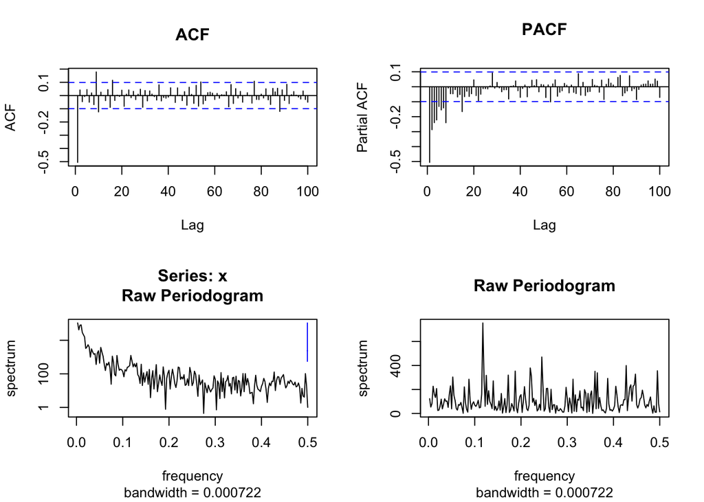

```r
pmts=ts(amazon$Close,frequency=1)
par(mfrow=c(2,2))
# acf(pmts,100)
acf(diff(diff(pmts)),100,main="ACF")
pacf(diff(diff(pmts)),100,main="PACF")
spectrum(pmts)
a=spec.pgram(diff(pmts),taper=0,log="no",main="Raw Periodogram")
```

```r
# abline(v=1/5,lty="dotted")
# testarma=Arima(pmts,order=c(8,0,2))
# pmdarmaforecast=forecast.Arima(testarma,h=25)
 par(mfrow=c(2,1))
# plot.forecast(pmdarmaforecast)

spm0=Arima(pmts,order=c(8,1,2),seasonal=list(order=c(1,1,0),period=8))
#spm0$aic
pmdarmaforecast1=forecast.Arima(spm0,h=25)

plot.forecast(pmdarmaforecast1,ylim=c(250,700),main="Forecast")

amazon_real = as.data.frame(get.hist.quote(instrument='AMZN',start='2014-09-08',end='2016-4-30'))
```

```
## time series ends   2016-04-27
```

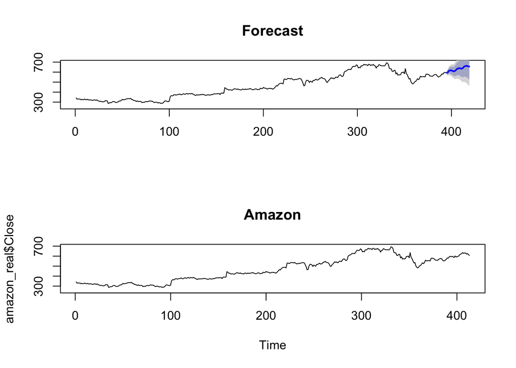

```r
plot.ts(amazon_real$Close,ylim=c(250,700),main="Amazon")
```

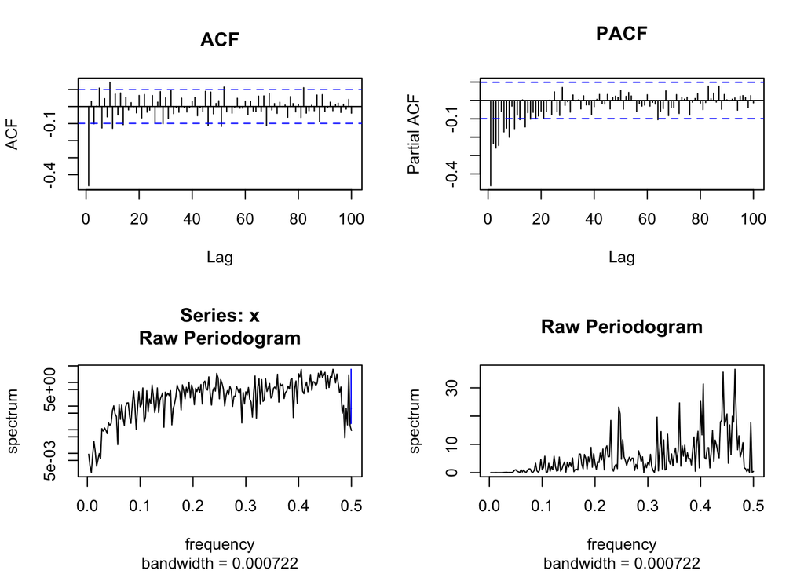

```r
pmts=ts(facebook$Close,frequency=1)
par(mfrow=c(2,2))
# acf(pmts,100)
acf(diff(diff(pmts)),100,main="ACF")
pacf(diff(diff(pmts)),100,main="PACF")
spectrum(diff(diff(pmts)))
a=spec.pgram(diff(diff(pmts)),taper=0,log="no",main="Raw Periodogram")
```

```r
# abline(v=1/5,lty="dotted")
testarma=Arima(pmts,order=c(9,2,2))
pmdarmaforecast=forecast.Arima(testarma,h=27)
par(mfrow=c(2,1))
plot.forecast(pmdarmaforecast,ylim=c(70,130),main="Forecast")

facebook_real = as.data.frame(get.hist.quote(instrument='FB',start='2014-09-08',end='2016-4-30'))
```

```
## time series ends   2016-04-27
```

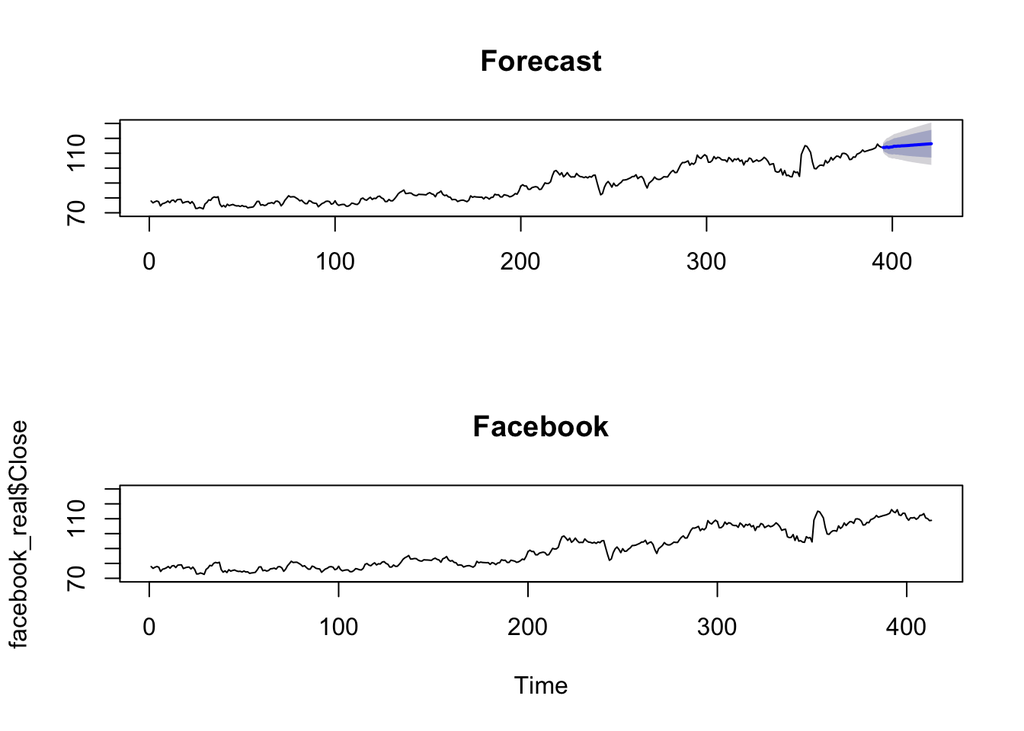

```r
plot.ts(facebook_real$Close,ylim=c(70,130),main="Facebook")
```

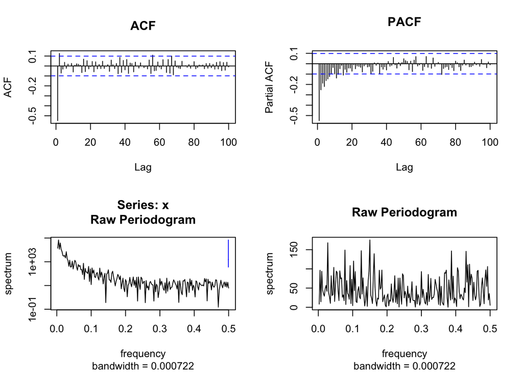

```r
pmts_l=ts(linkedin$Close,frequency=1)
par(mfrow=c(2,2))
# acf(pmts_l,100)
acf(diff(diff(pmts_l)),100,main="ACF")
pacf(diff(diff(pmts_l)),100,main="PACF")
spectrum(pmts_l)
a=spec.pgram(diff(pmts_l),taper=0,log="no",main="Raw Periodogram")
```

```r
# abline(v=1/5,lty="dotted")
testarma_l=Arima(pmts_l,order=c(7,1,2))
pmdarmaforecast_l=forecast.Arima(testarma_l,h=25)
par(mfrow=c(2,1))
plot.forecast(pmdarmaforecast_l,main="Forecast")

linkedin_real = as.data.frame(get.hist.quote(instrument='LNKD',start='2014-09-08',end='2016-4-30'))
```

```
## time series ends   2016-04-27
```

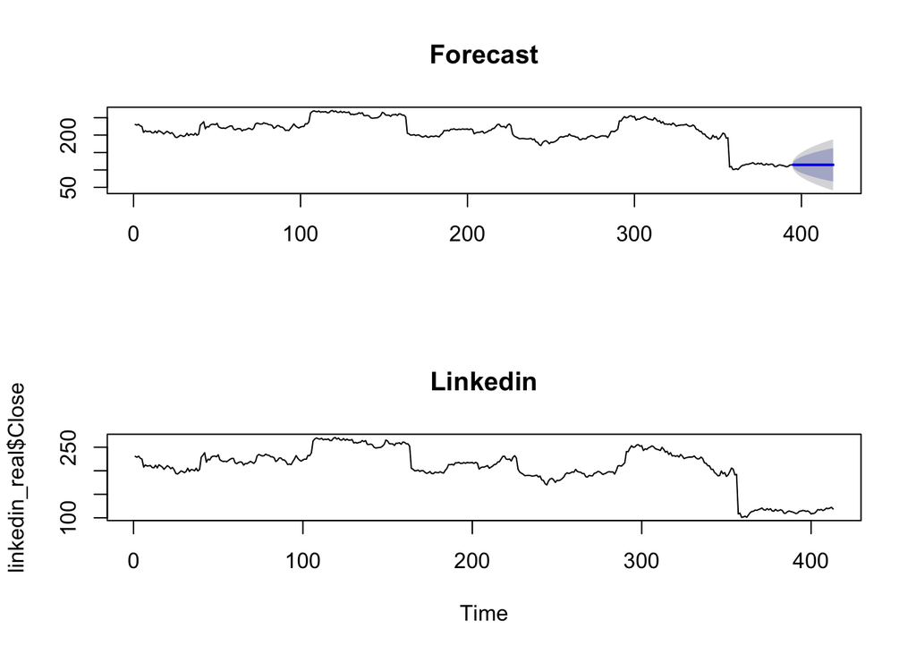

```r
plot.ts(linkedin_real$Close,main="Linkedin")
```

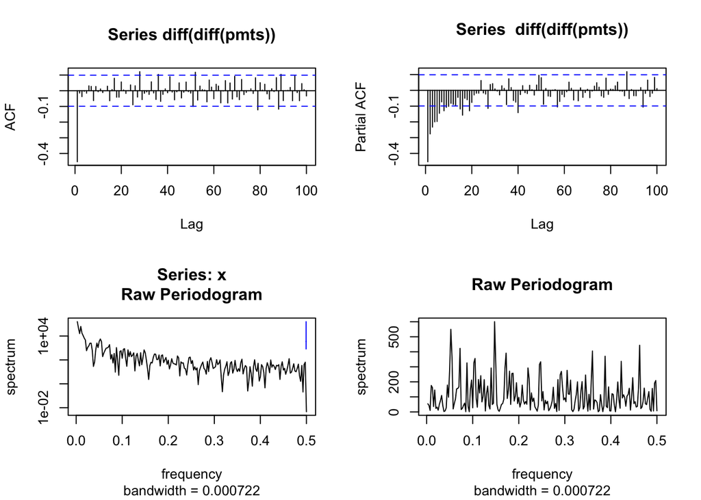

```r
pmts=ts(google$Close,frequency=1)
par(mfrow=c(2,2))
# acf(pmts,100)
acf(diff(diff(pmts)),100)
pacf(diff(diff(pmts)),100)
spectrum(pmts)
a=spec.pgram(diff(pmts),taper=0,log="no",main="Raw Periodogram")
```

```r
# abline(v=1/5,lty="dotted")
testarma=Arima(pmts,order=c(8,0,1))
pmdarmaforecast=forecast.Arima(testarma,h=25)
par(mfrow=c(2,1))
plot.forecast(pmdarmaforecast,main="Forecast")

google_real = as.data.frame(get.hist.quote(instrument='GOOG',start='2014-09-08',end='2016-4-30'))
```

```
## time series ends   2016-04-27
```

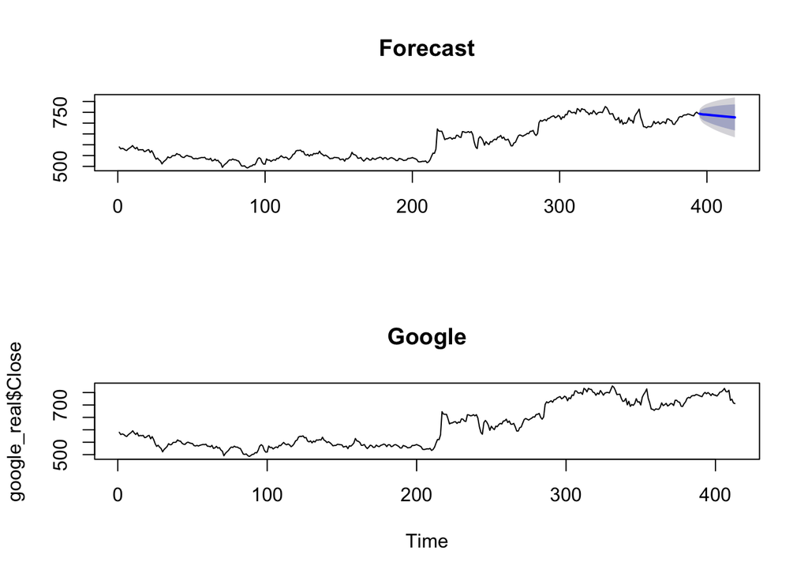

```r
plot.ts(google_real$Close,main="Google")
```

**Problems:**

1. Time series only takes the past Close price while the forecast Close price may also depend on other factors.
2. Forecasting time series can be a very hard task due to the inherent uncertainty nature of these systems. It seems very difficult to tell whether a series is stochastic or deterministic chaotic or some combination of these states. More generally, the extent to which a non-linear deterministic process retains its properties when corrupted by noise is also unclear. The noise can affect a system in different ways even though the equations of the system remain deterministic. Since a single reliable statistical test for chaoticity is not available, combining multiple tests is a crucial aspect, especially when one is dealing with limited and noisy data sets like in economic and financial time series.
3. The problem with using time series analysis as a tool for predicting in finance is that the underlying structure of the data is not ARIMA nor some combination of periodic functions so time series will not work. For differencing used in ARIMA, it has disadvantages including over-correcting for trends, which skews the correlations in a negative direction.

**Neural Network**

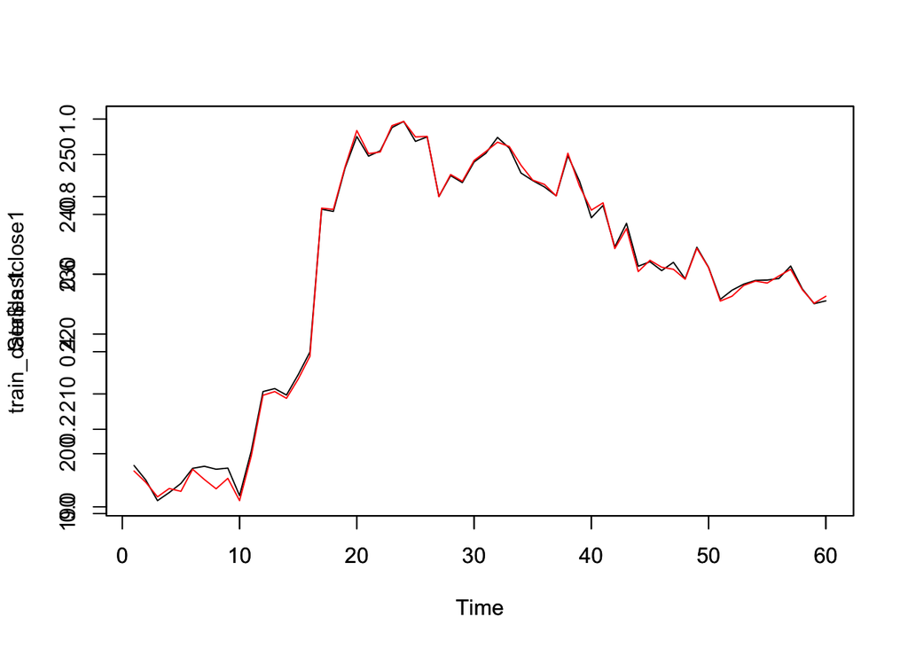

[figure not shown]

```r
lastclose1 = tail(linkedin$Close,60)
lastopen1 = tail(linkedin$Open,60)
lasthigh1 = tail(linkedin$High,60)
lastlow1 = tail(linkedin$Low,60)

lastclose2 = linkedin$Close[275:334]
lastopen2 = linkedin$Open[275:334]
lasthigh2 = linkedin$High[275:334]
lastlow2 = linkedin$Low[275:334]

lastclose3 = linkedin$Close[215:274]
lastopen3 = linkedin$Open[215:274]
lasthigh3 = linkedin$High[215:274]
lastlow3 = linkedin$Low[215:274]

lastclose4 = linkedin$Close[155:214]
lastopen4 = linkedin$Open[155:214]
lasthigh4 = linkedin$High[155:214]
lastlow4 = linkedin$Low[155:214]

lastclose5 = linkedin$Close[95:154]
lastopen5 = linkedin$Open[95:154]
lasthigh5 = linkedin$High[95:154]
lastlow5 = linkedin$Low[95:154]

test_data <- data.frame(cbind(lastclose1,lastopen1,lasthigh1,lastlow1,
                               lastclose2,lastopen2,lasthigh2,lastlow2,
                               lastclose3,lastopen3,lasthigh3,lastlow3,
                               lastclose4,lastopen4,lasthigh4,lastlow4
                               ))

train_data <- data.frame(cbind(lastclose2,lastopen2,lasthigh2,lastlow2,
                         lastclose3,lastopen3,lasthigh3,lastlow3,
                         lastclose4,lastopen4,lasthigh4,lastlow4,
                         lastclose5,lastopen5,lasthigh5,lastlow5))
colnames(train_data) <- c("lastclose1","lastopen1","lasthigh1","lastlow1",
                          "lastclose2","lastopen2","lasthigh2","lastlow2",
                          "lastclose3","lastopen3","lasthigh3","lastlow3",
                          "lastclose4","lastopen4","lasthigh4","lastlow4")
#You can choose different methods to scale the data (z-normalization, min-max scale, etc…).
#I chose to use the min-max method and scale the data in the interval [0,1].
#Usually scaling in the intervals [0,1] or [-1,1] tends to give better results.
maxs <- apply(train_data, 2, max)
mins <- apply(train_data, 2, min)
scaled_train <- as.data.frame(scale(train_data, center = mins, scale = maxs - mins))
maxs <- apply(test_data, 2, max)
mins <- apply(test_data, 2, min)
scaled_test <- as.data.frame(scale(test_data, center = mins, scale = maxs - mins))

#Train nn with scaled training data
set.seed(123)
net_linkedin_last <- neuralnet(lastclose1 ~(lastclose2+lastopen2+lasthigh2+lastlow2+
                                        lastclose3+lastopen3+lasthigh3+lastlow3+
                                         lastclose4+lastopen4+lasthigh4+lastlow4),
                               scaled_train, err.fct = "sse", hidden = c(14,3),
                            threshold=0.001,likelihood = TRUE,linear.output = TRUE)
# plot(net_linkedin_last)

net.results_last <- compute(net_linkedin_last, scaled_train[,5:16])
pr.nn_last <- net.results_last$net.result
plot.ts(train_data$lastclose1)
par(new=TRUE)
plot.ts(pr.nn_last,col='red')
```

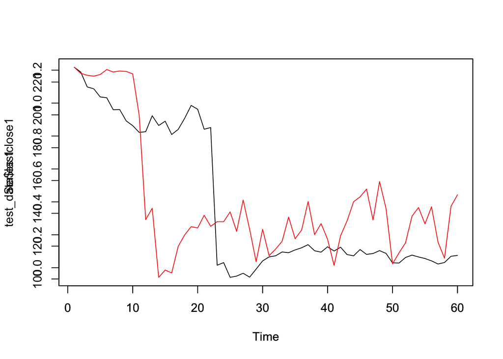

```r
net.results_last <- compute(net_linkedin_last, scaled_test[,5:16])
pr.nn_last <- net.results_last$net.result
plot.ts(test_data$lastclose1)
# plot.ts(train_data$lastclose1)
par(new=TRUE)
plot.ts(pr.nn_last,col='red')
```

```r
# plot(scaled_test$lastclose1,pr.nn_last,col='red',main='Real vs predicted NN',pch=18,cex=0.7)
# abline(0,1,lwd=2)
# legend('bottomright',legend='NN',pch=18,col='red', bty='n')
```

Artificial neural network: Artificial neural network (ANN) is a machine learning model to estimate the function of inputs. It is composed of many neuron-like nodes which have connections with each other.